# Exercise 3.2: Navarre weather stations. Kriging, co-kriging and universal kriging

Author

Aritz Adin and Tomás Goicoa

Published

Dec/2026

# 1 Objectives

In this exercise you will replicate the analysis of Example 3.3 with data from another day, and extend it with a third method:

- Predict the **maximum temperature** in Navarre on 20 February 2011 using **ordinary kriging** and **co-kriging** with the minimum temperature as secondary variable.
- Predict it using **universal kriging** with the **altitude** as a covariate (Chapter 2).

Try to solve each task on your own before opening the solution.

# 2 Packages

```r
library(dplyr)
library(gstat)
library(mapSpain)
library(sf)
library(tmap)
```

# 3 Description of the data

The data contain the daily records of 83 manual weather stations in Navarre on 20 February 2011, with the same variables as in Example 3.3:

```r
stations <- read.csv("https://raw.githubusercontent.com/aritz-adin/MUSIGT_2026-27/main/data/manual_20110220.csv",
                     colClasses = c(CODE = "character"))

stations_sf <- stations |>
  st_as_sf(coords=c("X","Y"), crs=25830)
```

Predictions are computed on a regular grid of 1 km covering Navarre. The file `Navarra_grid_1km.csv` contains the coordinates (`X`, `Y`) of each node and its altitude (`Z`, in metres), which will be needed for universal kriging:

```r
grid_z <- read.csv("https://raw.githubusercontent.com/aritz-adin/MUSIGT_2026-27/main/data/Navarra_grid_1km.csv") |>
  st_as_sf(coords=c("X","Y"), crs=25830)

Navarra <- esp_get_prov(prov = "Navarra") |>
  st_transform(crs = 25830)
```

# 4 Tasks

## 4.1 Exploratory analysis

Compute the correlation of the maximum temperature with the minimum temperature and with the altitude.

- Which of the two auxiliary variables seems more useful to predict the maximum temperature?
- Compare the correlation between the maximum and minimum temperatures with the one obtained in Example 3.3.

**TipSolution**

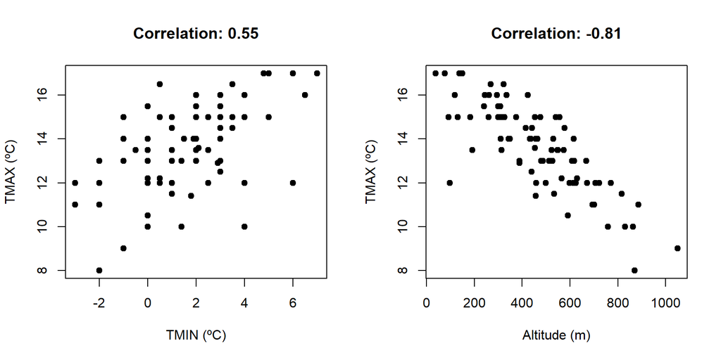

```r
par(mfrow = c(1, 2))
plot(stations$TMIN, stations$TMAX, pch = 19,
     xlab = "TMIN (ºC)", ylab = "TMAX (ºC)",
     main = paste("Correlation:", round(cor(stations$TMAX, stations$TMIN), 2)))
plot(stations$Z, stations$TMAX, pch = 19,
     xlab = "Altitude (m)", ylab = "TMAX (ºC)",
     main = paste("Correlation:", round(cor(stations$TMAX, stations$Z), 2)))
```

- The maximum temperature is much more strongly related to the altitude (-0.81) than to the minimum temperature (0.55).
- The correlation between the maximum and minimum temperatures is clearly higher than in Example 3.3 (0.25).

## 4.2 Ordinary kriging

Compute the empirical semivariogram of the maximum temperature (with `width = 10000`, as in Example 3.3), fit a spherical model with a nugget effect, and predict the maximum temperature on `grid_z`.

- Does the empirical semivariogram level off this time?

**TipSolution**

```r
v_tmax <- variogram(TMAX ~ 1, stations_sf, width = 10000)
vgm_tmax <- fit.variogram(v_tmax, model=vgm(psill=2, model="Sph",
                                            range=50000, nugget=1))
vgm_tmax
```

```
  model    psill    range
1   Nug 1.165497     0.00
2   Sph 3.012781 63050.71
```

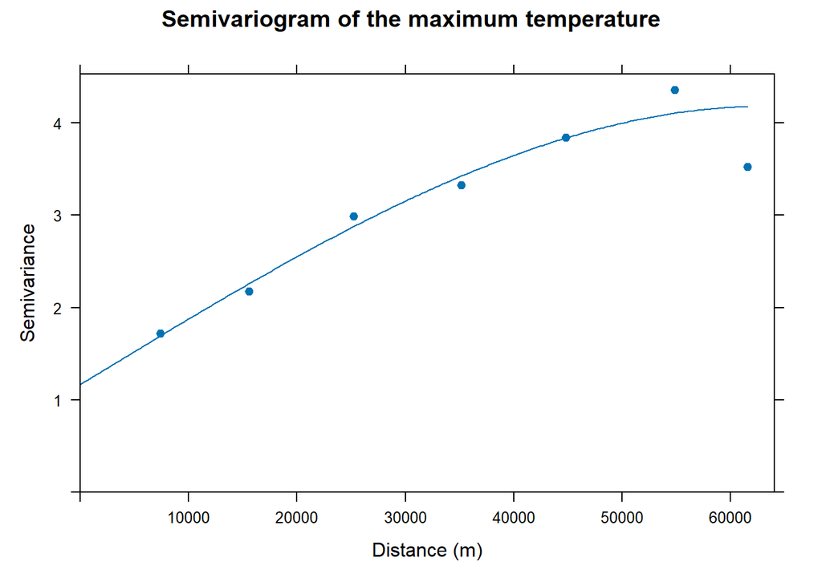

```r
plot(v_tmax, vgm_tmax, pch = 19,
     xlab = "Distance (m)", ylab = "Semivariance",
     main = "Semivariogram of the maximum temperature")
```

```r
pred_krig <- krige(TMAX ~ 1, stations_sf, grid_z, model=vgm_tmax, debug.level=0)
```

Unlike in Example 3.3, the empirical semivariogram **levels off** at a sill of about 4.18, with a range of about 63 km.

## 4.3 Co-kriging with the minimum temperature

Fit a linear model of coregionalization for the maximum and minimum temperatures, using the model of the previous task, and predict the maximum temperature on `grid_z` with co-kriging.

**TipSolution**

```r
g <- gstat(NULL, id = "TMAX", formula = TMAX ~ 1, data = stations_sf)
g <- gstat(g,    id = "TMIN", formula = TMIN ~ 1, data = stations_sf)

v <- variogram(g, width = 10000)
lmc <- fit.lmc(v, g, model=vgm_tmax)
lmc$model
```

```
$TMAX
  model    psill    range
1   Nug 1.165497     0.00
2   Sph 3.012781 63050.71

$TMAX.TMIN
  model       psill    range
1   Nug -0.06064001     0.00
2   Sph  2.82104372 63050.71

$TMIN
  model    psill    range
1   Nug 1.230058     0.00
2   Sph 4.366494 63050.71
```

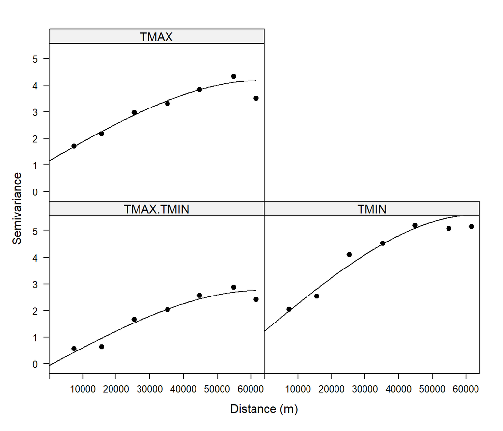

```r
plot(v, lmc, pch = 19, col = "black",
     xlab = "Distance (m)", ylab = "Semivariance",
     scales = list(alternating = 1, tck = c(1, 0)))
```

```r
pred_cokrig <- predict(lmc, grid_z, debug.level=0)
```

The cross-semivariogram is clearly structured, with a sill of about 2.76: the spatial correlation between both temperatures is stronger than in Example 3.3.

## 4.4 Universal kriging with the altitude

Compute the empirical semivariogram of the residuals of the model with altitude (`variogram(TMAX ~ Z, ...)`, with `width = 10000`), and predict the maximum temperature on `grid_z` with universal kriging.

- What does the semivariogram of the residuals look like? Fit an appropriate model.
- What does this mean?

**Note**

The covariate must have the **same name** in the data (`stations_sf`) and in the prediction grid (`grid_z`), so that `krige()` can evaluate the formula `TMAX ~ Z` at the prediction locations.

**TipSolution**

```r
v_res <- variogram(TMAX ~ Z, stations_sf, width = 10000)
v_res
```

```
   np      dist    gamma dir.hor dir.ver   id
1  77  7375.017 1.310484       0       0 var1
2 257 15559.160 1.387442       0       0 var1
3 353 25239.802 1.149994       0       0 var1
4 407 35168.687 1.120912       0       0 var1
5 432 44814.346 1.244897       0       0 var1
6 435 54865.552 1.231796       0       0 var1
7 133 61592.035 1.090076       0       0 var1
```

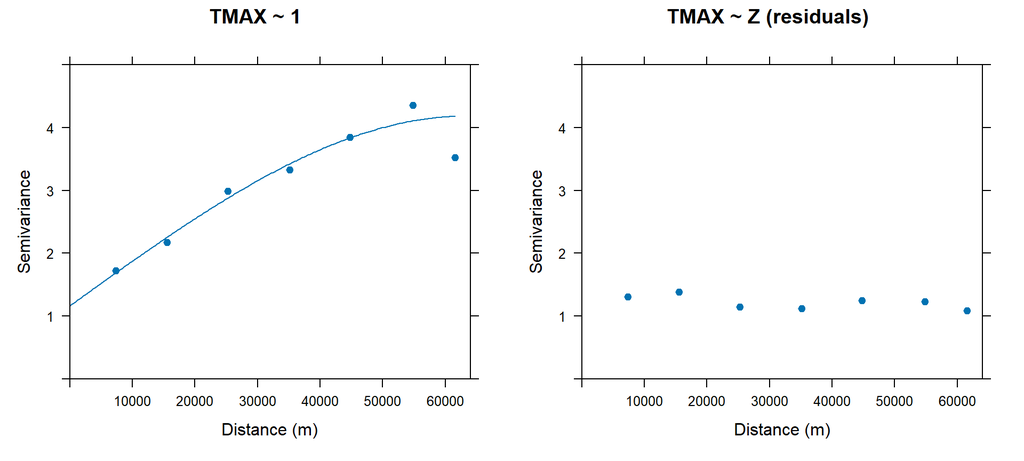

```r
library(lattice)
p1 <- plot(v_tmax, vgm_tmax, pch = 19, ylim = c(0, 5),
           xlab = "Distance (m)", ylab = "Semivariance", main = "TMAX ~ 1")
p2 <- plot(v_res, pch = 19, ylim = c(0, 5),
           xlab = "Distance (m)", ylab = "Semivariance", main = "TMAX ~ Z (residuals)")
print(p1, split = c(1, 1, 2, 1), more = TRUE)
print(p2, split = c(2, 1, 2, 1))
```

The semivariogram of the residuals is **flat**: the semivariance is approximately the same at all distances. Altitude explains the spatial structure of the maximum temperature, and the residuals show no spatial dependence. Therefore, the appropriate model is a **pure nugget effect**:

```r
vgm_res <- fit.variogram(v_res, model=vgm(psill=1, model="Nug"))
vgm_res
```

```
  model    psill range
1   Nug 1.283103     0
```

```r
pred_uk <- krige(TMAX ~ Z, stations_sf, grid_z, model=vgm_res, debug.level=0)
```

**Note**

With a pure nugget model, the residuals at different locations are uncorrelated, so universal kriging is equivalent to a **linear regression** of the maximum temperature on the altitude: the predictions do not depend on the nearby stations, only on the altitude of each location.

## 4.5 Maps of the predictions

Draw the maps of the predictions of the three methods.

- Which method shows more detail? Why?
- The highest station is at 1050 m, but some areas of Navarre are above 2000 m. Are the universal kriging predictions reliable in those areas?

**TipSolution**

```r
pred_sf <- grid_z |>
  mutate(krig_pred   = pred_krig$var1.pred,
         cokrig_pred = pred_cokrig$TMAX.pred,
         uk_pred     = pred_uk$var1.pred) |>
  st_buffer(dist=500, endCapStyle="SQUARE")
```

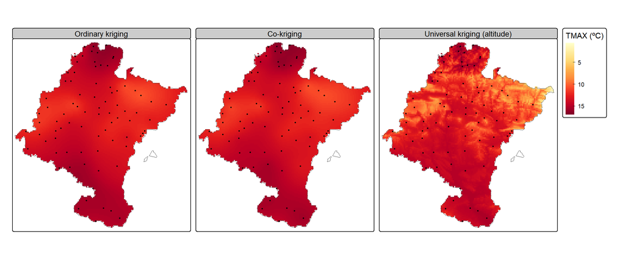

```r
tmap_mode("plot")

tm_shape(pred_sf) +
  tm_polygons(fill = c("krig_pred", "cokrig_pred", "uk_pred"),
              fill.scale  = tm_scale_continuous(values = "brewer.yl_or_rd"),
              fill.legend = tm_legend(title = "TMAX (ºC)"),
              fill.free = FALSE,    # common colour scale
              col = NULL) +         # no cell borders
  tm_facets_wrap(nrow=1) +
  tm_shape(Navarra) + tm_borders() +
  tm_shape(stations_sf) + tm_dots(fill="black", size=0.2) +
  tm_layout(panel.labels = c("Ordinary kriging", "Co-kriging",
                             "Universal kriging (altitude)"))
```

- The ordinary kriging and co-kriging maps are very similar and smooth: they only use the information of the stations.
- The universal kriging map shows much more detail, because it uses the altitude of each node of the grid: it reproduces the relief of Navarre (valleys, mountain ranges and the Pyrenees).
- In the areas above the highest station (about 7% of the grid nodes), universal kriging **extrapolates** the linear relationship with altitude beyond the range of the observed data, **so the predictions must be interpreted with caution**.

## 4.6 Cross-validation

Compare the three methods using leave-one-out cross-validation (MAE and RMSE). Remember to compare ordinary kriging and co-kriging fairly (see Example 3.3).

- Does co-kriging improve on ordinary kriging?
- Why does universal kriging improve much more than co-kriging?

**TipSolution**

```r
# Ordinary kriging
cv_krig <- krige.cv(TMAX ~ 1, stations_sf, model=vgm_tmax, nfold=nrow(stations_sf),
                    debug.level=0)

# Co-kriging
cv_cokrig <- gstat.cv(lmc, nfold=nrow(stations_sf), remove.all=TRUE, debug.level=0)

# Universal kriging
cv_uk <- krige.cv(TMAX ~ Z, stations_sf, model=vgm_res, nfold=nrow(stations_sf),
                  debug.level=0)

cv_results <- data.frame(
  Method = c("Ordinary kriging", "Co-kriging (TMIN)", "Universal kriging (altitude)"),
  MAE    = c(mean(abs(cv_krig$residual)), mean(abs(cv_cokrig$residual)),
             mean(abs(cv_uk$residual))),
  RMSE   = c(sqrt(mean(cv_krig$residual^2)), sqrt(mean(cv_cokrig$residual^2)),
             sqrt(mean(cv_uk$residual^2)))
)
cv_results |> mutate(across(c(MAE, RMSE), \(x) round(x, 3)))
```

```
                        Method   MAE  RMSE
1             Ordinary kriging 1.129 1.442
2            Co-kriging (TMIN) 1.104 1.427
3 Universal kriging (altitude) 0.898 1.163
```

- Co-kriging **hardly improves** on ordinary kriging (RMSE of 1.427 vs. 1.442), even though the correlation between both temperatures is higher than in Example 3.3. The minimum temperature has been measured at the same stations, so it does not provide information at new locations: **a high correlation is not enough**.
- Universal kriging clearly outperforms both methods (RMSE of 1.163), because:
  - altitude is strongly related to the maximum temperature;
  - altitude is known at **every location**, so it provides information where there are no stations.
- When an auxiliary variable is available everywhere, it is better to include it in the mean of the model (universal kriging) than to use it as a secondary variable in co-kriging.